# biomass – Big Sur SOD Analysis

## Objectives: quantifying fire/disease impacts

- Quantify biomass, stem density changes pre to post fire. Compare across burn scar, species, and status.
  - Used mixed effects models to understand underlying relationships.
- Track stems through time to quantify rates of mortality, snag fall and CWD decomposition.
  - Use survival analysis (mortality), ?? (snag fall), regression (CWD decomp.)

### Needed libraries

```r
library(tidyverse)
library(broom)
library(gtsummary)
library(survival)
library(ggsurvfit)
library(lme4)
library(lmerTest)
library(here)
library(knitr)
library(patchwork)
library(gt)
library(kableExtra)
library(ggalluvial)
library(broom)
library(gtsummary)
library(survival)
library(ggsurvfit)
```

### Recycled functions

```r
read_me <- function(path){
  read_csv(here("data", path))
}
export_image <- function(img, path){
  ggsave(filename = here("exports", path), plot=img, width=12, height=8)
}

climate_theme <- function(color = "slategray1") {
  theme(
  plot.title = element_text(
      size = 16,
      family = "Times New Roman",
      color = "black",
      margin = margin(b = 15)
    ),
    # add border 1)
    panel.border = element_rect(colour = "black", fill = NA, linetype = 1),
    # color background 2)
    panel.background = element_rect(fill = color),
    # modify grid 3)
    panel.grid.major.x = element_blank(),
    panel.grid.minor.x = element_blank(),
    panel.grid.major.y =  element_blank(),
    panel.grid.minor.y = element_blank(),
    # modify text, axis and colour 4) and 5)
    axis.text = element_text(colour = "black",  family = "Times New Roman"),
    axis.title = element_text(colour = "black", family = "Times New Roman"),
    axis.ticks = element_line(colour = "black"),
    legend.position = "right"
  )
}
# darkolivegreen3
```

## Univariate statistics of fire and disease impacts

### Living Biomass changes

```r
biomass_changes <- read_me("./clean/post_fire_summary.csv")
burn_change <- function(burn, time1) {
  df <- biomass_changes |>
    filter(BurnScar == burn) |>
    select(!c(Elevation,Slope,Fire)) |>
    mutate(Pre = case_when(
      SampleYear <= time1 ~ "Pre",
      SampleYear >=  time1 ~ "Post",
      TRUE ~ "NA"))
  df_mod1 <- df |>
    filter(Pre %in% c("Pre","Post")) |>
    group_by(Plot, Species, BurnScar, PRam, Pre) |>
    summarise(
      TotalStem   = sum(TotalStem, na.rm = TRUE),
      LiveBiomass = sum(LiveBiomass, na.rm = TRUE),
      .groups = "drop"
    ) |>
    pivot_wider(names_from="Pre", values_from=c("TotalStem","LiveBiomass"))
  # only want to evaluate data with both pre and post
  df_mod2 <- na.omit(df_mod1)
  df_mod3 <- df_mod2 |>
    mutate(ChangeStem = TotalStem_Post - TotalStem_Pre,
      ChangeBiomass = LiveBiomass_Post - LiveBiomass_Pre) |>
    select(c(1,2,3,4,9,10))
  return(df_mod3)
}
# apply summary function to dataset we want
sites_tree <- tibble(
  burn  = c("dolan", "sober", "chalk", "control", "dolan_chalk", "sober_chalk"),
  time1 = c(2020, 2016, 2007, 2016, 2007, 2007)
)
demo_tree <- pmap_df(sites_tree, burn_change)

post_fire_summary_biomass <- demo_tree |>
  group_by(Species, BurnScar, PRam) |>
  summarize( n = n(),
            MeanStemChange = mean(ChangeStem, na.rm=TRUE),
            MeanBiomassChange = mean(ChangeBiomass, na.rm=TRUE),
            MedianStemChange    = median(ChangeStem, na.rm = TRUE),
            MedianBiomassChange = median(ChangeBiomass, na.rm = TRUE),
            SdStemChange = sd(ChangeStem, na.rm=TRUE),
            SdBiomassChange = sd(ChangeBiomass, na.rm=TRUE)
)

kable(post_fire_summary_biomass)
```

| Species | BurnScar | PRam | n | MeanStemChange | MeanBiomassChange | MedianStemChange | MedianBiomassChange | SdStemChange | SdBiomassChange |
| --- | --- | --- | --- | --- | --- | --- | --- | --- | --- |
| ARME | chalk | 1 | 4 | 64.250000 | -4735.6891 | 31.0 | -2.475208e+04 | 92.211261 | 95314.143 |
| ARME | control | 1 | 1 | 0.000000 | -4706.5006 | 0.0 | -4.706501e+03 | NA | NA |
| ARME | dolan | 0 | 3 | -25.333333 | 2931.9403 | -24.0 | -1.358863e+02 | 25.026653 | 12853.139 |
| ARME | dolan | 1 | 2 | -58.500000 | -27506.5312 | -58.5 | -2.750653e+04 | 6.363961 | 34618.900 |
| ARME | dolan_chalk | 0 | 2 | -9.000000 | -51232.8484 | -9.0 | -5.123285e+04 | 11.313709 | 68145.505 |
| ARME | sober | 0 | 1 | 6.000000 | 90987.8879 | 6.0 | 9.098789e+04 | NA | NA |
| ARME | sober | 1 | 7 | 9.857143 | -40081.6650 | 9.0 | -4.193882e+04 | 8.355209 | 176753.024 |
| ARME | sober_chalk | 0 | 13 | 45.384615 | -30509.1849 | 13.0 | -6.785663e+03 | 88.262429 | 57134.049 |
| ARME | sober_chalk | 1 | 5 | 40.200000 | 126975.2275 | 61.0 | 2.625905e+03 | 37.943379 | 265297.811 |
| LIDE | chalk | 1 | 8 | 146.250000 | -58083.0346 | 100.0 | -9.858739e+03 | 160.361868 | 109802.840 |
| LIDE | control | 1 | 8 | -15.625000 | -106051.4322 | -0.5 | 1.018131e+02 | 29.310834 | 225043.485 |
| LIDE | dolan | 0 | 1 | -491.000000 | -55587.7454 | -491.0 | -5.558775e+04 | NA | NA |
| LIDE | dolan_chalk | 0 | 10 | 10.200000 | 14074.8575 | -9.0 | -1.183408e+02 | 88.882944 | 188749.720 |
| LIDE | dolan_chalk | 1 | 5 | -6.600000 | -7345.3124 | 3.0 | -4.498775e+04 | 86.984481 | 170903.905 |
| LIDE | sober | 0 | 1 | -45.000000 | 222393.2176 | -45.0 | 2.223932e+05 | NA | NA |
| LIDE | sober | 1 | 23 | -27.086956 | -150404.8317 | -25.0 | -2.304594e+04 | 77.100827 | 335708.111 |
| LIDE | sober_chalk | 0 | 10 | 146.600000 | 289236.8865 | 6.0 | 1.772587e+05 | 367.269867 | 336650.570 |
| LIDE | sober_chalk | 1 | 17 | 55.294118 | 20792.4553 | 10.0 | -2.266228e+03 | 134.980908 | 212413.670 |
| PIPO | dolan | 0 | 1 | 1.000000 | 62751.3028 | 1.0 | 6.275130e+04 | NA | NA |
| PIPO | dolan_chalk | 0 | 2 | -0.500000 | -7988.8256 | -0.5 | -7.988826e+03 | 2.121320 | 17540.097 |
| PSME | dolan_chalk | 0 | 1 | 0.000000 | 13612.6089 | 0.0 | 1.361261e+04 | NA | NA |
| PSME | sober_chalk | 0 | 2 | 2.500000 | 316585.6055 | 2.5 | 3.165856e+05 | 2.121320 | 265102.306 |
| PSME | sober_chalk | 1 | 1 | -14.000000 | 3572.0807 | -14.0 | 3.572081e+03 | NA | NA |
| QUAG | chalk | 1 | 4 | 40.250000 | 416239.9653 | 27.5 | 3.969031e+05 | 42.279822 | 460112.432 |
| QUAG | control | 0 | 1 | -2.000000 | -54147.5406 | -2.0 | -5.414754e+04 | NA | NA |
| QUAG | control | 1 | 4 | -8.750000 | -263712.0880 | -10.5 | -1.476638e+05 | 6.701990 | 334921.250 |
| QUAG | dolan | 0 | 4 | -1.500000 | -16041.8932 | -1.0 | -1.480000e+04 | 1.914854 | 25112.150 |
| QUAG | dolan | 1 | 6 | -15.333333 | -525585.9305 | -15.5 | -5.281188e+05 | 8.640988 | 367868.553 |
| QUAG | dolan_chalk | 0 | 5 | 12.000000 | 285369.4926 | 4.0 | 6.338939e+04 | 17.677670 | 470390.524 |
| QUAG | dolan_chalk | 1 | 1 | 93.000000 | 957347.7313 | 93.0 | 9.573477e+05 | NA | NA |
| QUAG | sober | 1 | 3 | -2.666667 | -42502.4767 | -2.0 | -4.243287e+04 | 2.081666 | 24618.375 |
| QUAG | sober_chalk | 0 | 5 | 5.200000 | 166882.2258 | 1.0 | -3.620684e-01 | 16.513631 | 374822.998 |
| QUAG | sober_chalk | 1 | 6 | 10.333333 | 192888.9558 | 4.0 | 4.297574e+04 | 21.924111 | 497971.455 |
| SESE | chalk | 1 | 6 | 86.333333 | 651901.7457 | 60.5 | 1.166211e+05 | 68.289580 | 1162602.563 |
| SESE | control | 1 | 7 | -6.000000 | -620806.6909 | -4.0 | 1.151147e+04 | 36.701499 | 1458116.896 |
| SESE | dolan | 0 | 4 | -198.250000 | -1553061.8681 | -137.5 | -8.163049e+05 | 285.928167 | 2173412.246 |
| SESE | dolan | 1 | 7 | -147.857143 | -340206.7505 | -52.0 | -2.253798e+04 | 188.694134 | 1010944.136 |
| SESE | dolan_chalk | 0 | 12 | 8.083333 | 217139.9624 | -9.5 | 1.618207e+04 | 46.947666 | 438548.455 |
| SESE | dolan_chalk | 1 | 7 | 27.142857 | 134849.0076 | 7.0 | 1.972146e+05 | 79.186338 | 311658.223 |
| SESE | sober | 1 | 14 | 34.428571 | -239774.3632 | 33.0 | -1.041434e+04 | 45.705940 | 833842.398 |
| SESE | sober_chalk | 0 | 9 | 132.444444 | 1387715.9646 | 52.0 | 1.336848e+06 | 227.080994 | 1431761.979 |
| SESE | sober_chalk | 1 | 10 | 6.400000 | 127542.5142 | 4.5 | 1.035971e+05 | 66.079414 | 618960.074 |
| UMCA | chalk | 1 | 10 | 131.700000 | -425.3252 | 39.0 | -1.907246e+04 | 238.301886 | 150132.591 |
| UMCA | control | 0 | 1 | -99.000000 | -271080.0521 | -99.0 | -2.710801e+05 | NA | NA |
| UMCA | control | 1 | 8 | -16.500000 | -5963.2595 | -15.0 | 1.592105e+03 | 13.201731 | 27846.195 |
| UMCA | dolan | 0 | 6 | -22.000000 | -11305.2623 | -20.5 | -6.076462e+03 | 19.193749 | 16929.464 |
| UMCA | dolan | 1 | 8 | -125.750000 | -82444.9073 | -69.5 | -1.916584e+04 | 148.602778 | 132923.190 |
| UMCA | dolan_chalk | 0 | 8 | 16.000000 | 521.7103 | 1.0 | -8.991931e+02 | 36.909155 | 41603.312 |
| UMCA | dolan_chalk | 1 | 8 | -5.250000 | 11727.7062 | 8.5 | 8.382133e+02 | 104.075179 | 69982.406 |
| UMCA | sober | 1 | 19 | 63.947368 | -38030.0327 | 18.0 | -1.000048e+04 | 103.412590 | 67557.502 |
| UMCA | sober_chalk | 0 | 2 | 42.500000 | 1710.3947 | 42.5 | 1.710395e+03 | 23.334524 | 2508.224 |
| UMCA | sober_chalk | 1 | 13 | 385.307692 | 30200.5512 | 9.0 | -7.635790e+00 | 792.748634 | 82823.848 |

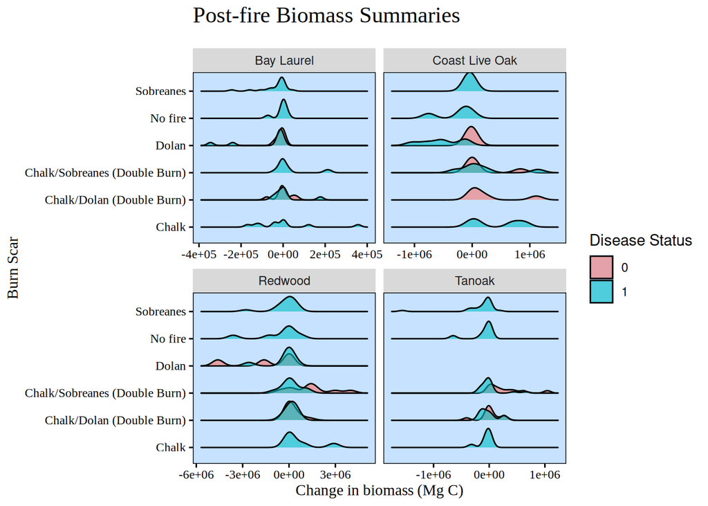

```r
library(ggridges)
red <- demo_tree |>
  filter(Species %in% c("SESE", "LIDE", "UMCA", "QUAG")) |>
  mutate(Species = recode_values(Species,
                                 "SESE" ~ "Redwood",
                                 "LIDE" ~ "Tanoak",
                                 "UMCA" ~ "Bay Laurel",
                                 "QUAG" ~ "Coast Live Oak"),
         BurnScar = recode_values(BurnScar,
                                  "sober_chalk" ~ "Chalk/Sobreanes (Double Burn)",
                                  "sober" ~ "Sobreanes",
                                  "dolan_chalk" ~ "Chalk/Dolan (Double Burn)",
                                  "dolan" ~ "Dolan",
                                  "control" ~ "No fire",
                                  "chalk" ~ "Chalk")) |>
  ggplot(aes(x = ChangeBiomass, y = BurnScar, fill = as.factor(PRam))) +
  geom_density_ridges(alpha = 0.6, scale= .7) +
  climate_theme() +
  facet_wrap(~Species, scales = "free_x") +
  labs(title = "Post-fire Biomass Summaries", x = "Change in biomass (Mg C)", y = "Burn Scar", fill = "Disease Status")

red
```

```r
ggsave("./fire-sums.png", red, width = 16, height = 10)
```

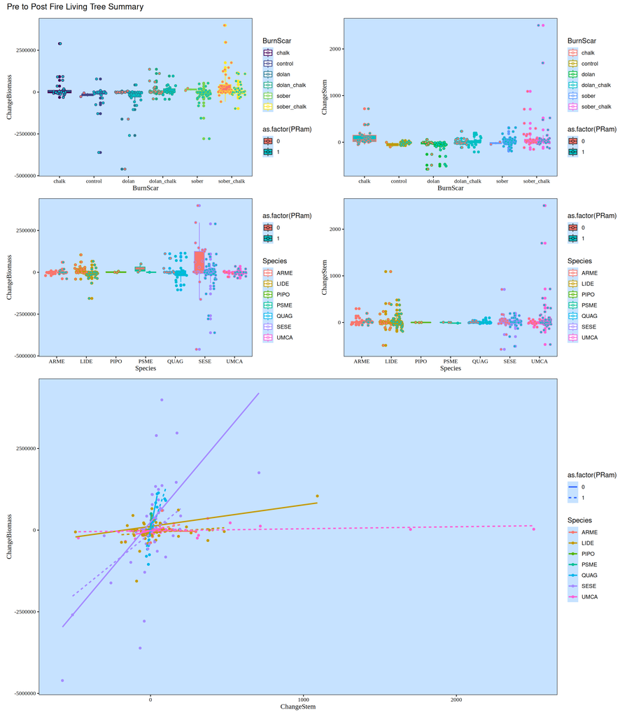

```r
den <- demo_tree |>
    ggplot(aes(x=ChangeStem, y= ChangeBiomass, color = Species, linetype = as.factor(PRam))) +
    geom_point() +
    geom_smooth(method = "lm", se =FALSE) +
    climate_theme()

dis <- demo_tree |>
    ggplot(aes(x=BurnScar, y= ChangeBiomass, color = BurnScar, fill = as.factor(PRam))) +
    geom_boxplot() +
    geom_jitter(shape = 21,
                position = position_jitterdodge(0.8)) +
    climate_theme() +
    scale_color_viridis_d()

dis2 <- demo_tree |>
    ggplot(aes(x=BurnScar, y= ChangeStem, color = BurnScar, fill = as.factor(PRam))) +
    geom_boxplot() +
    geom_jitter(shape = 21,
                position = position_jitterdodge(0.8)) +
    climate_theme()
dis3 <- demo_tree  |>
    ggplot(aes(x=Species, y= ChangeBiomass, color = Species, fill = as.factor(PRam))) +
    geom_boxplot() +
    geom_jitter(shape = 21,
                position = position_jitterdodge(0.8)) +
    climate_theme()

dis4 <- demo_tree |>
    ggplot(aes(x=Species, y= ChangeStem, color = Species, fill = as.factor(PRam))) +
    geom_boxplot() +
    geom_jitter(shape = 21,
                position = position_jitterdodge(0.8)) +
    climate_theme()


(dis + dis2) / (dis3 + dis4) / den +
  plot_annotation(title = "Pre to Post Fire Living Tree Summary") +
plot_layout(heights = c(1, 1, 2))
```

```r
plot_bio <- biomass_changes |>
  select(Plot, SampleYear, BurnScar,PRam, Fire)

tree_bio <- read_me("./treeBio.csv") |>
  left_join(plot_bio, by = c("Plot", "SampleYear"), relationship = "many-to-many") |>
  distinct() |>
  mutate(Status = case_when(
                            Status == "L" ~ "L",
                            TRUE ~ "D"))

pools <- tree_bio |>
  group_by(Plot, Species, SampleYear, Status, BurnScar, PRam, Fire) |>
  summarize(
            Biomass = sum(Biomass, na.rm = TRUE) * 20)

red_map <- pools |>
  filter(Species == "UMCA") |>
  filter(BurnScar == "sober") |>
  mutate(Period = ifelse(SampleYear < 2020, "Pre", "Post"))

red_map |>
  ggplot(aes(x = SampleYear, y = Biomass, linetype = Status, color = as.factor(PRam))) +
  geom_point() +
  geom_smooth(method = "lm")

ggplot(red_map,
       aes(axis1 = Biomass_D,
           axis2 = Biomass_L,
           fill = as.factor(PRam)
           )) +
  geom_alluvium(aes(fill = as.factor(PRam)), alpha = 0.7) +
  geom_stratum(width = 0.3, decreasing = FALSE)


is_alluvia_form(red_map,
                axes = "Status",
                weight = "Biomass",
                silent = FALSE)
```

[output not shown]

## Underlying drivers of biomass and stem density changes

### Mixed effects models

– Multiple regression with mixed effects models iterated across species  
- Attempt to understand drivers of biomass changes. Is disease and fire interacting to reduce biomass? Is it even across species.  
- Improvements: Run multiple models per species with different explanatory variables, take weighted AIC and weighted effects.  
**Questions I hope to answer**  
Which features, topographic or epidemiological, are driving biomass changes in Redwood forests?  
Is there a linear relationship between the fixed explanatory variables and biomass?

– P-values for fixed variables below the 0.05 threshold will allow us to reject our null hypothesis and indicate a linear relationship between a fixed explanatory variable and biomass.

#### Plot biomass changes

- Scaling values standardizes units? Worth doing?

**Interactions**

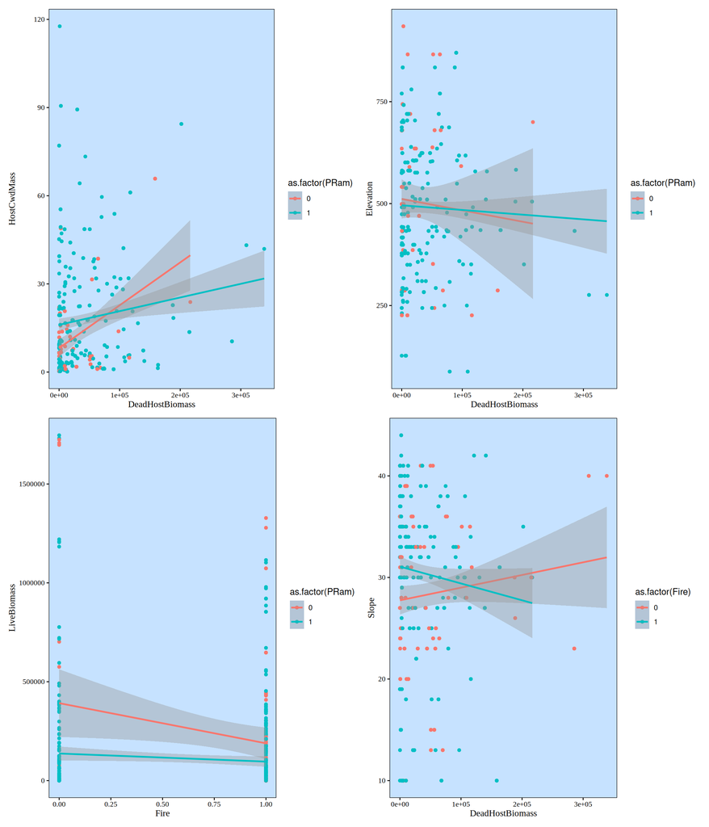

```r
biomass <-  read_me("clean/livebiomass_mixedmodel.csv")

int_me <- function(df,x,y,int) {
  df |>
    ggplot(aes(x={{x}},y={{y}},color=as.factor({{int}}),group=as.factor({{int}}))) +
      geom_point() +
      geom_smooth(method="lm") +
      climate_theme()
}

p1 <- int_me(biomass,DeadHostBiomass, HostCwdMass, PRam)
p2 <- int_me(biomass,DeadHostBiomass, Elevation, PRam)
p3 <- int_me(biomass,Fire, LiveBiomass,PRam)
p4 <- int_me(biomass,DeadHostBiomass, Slope, Fire)


(p1 + p2) / (p3 + p4)
```

**Other interactions to graph?**

**Adding time since fire,UMCA stem density**

```r
biomass1 <- biomass |>
  mutate(tFire = case_when(
                          BurnScar == "chalk" ~ SampleYear - 2008,
                          BurnScar == "sober" ~ SampleYear - 2016,
                          BurnScar == "dolan" ~ SampleYear - 2020,
                          BurnScar == "dolan_chalk" ~ SampleYear - 2020,
                          BurnScar == "sober_chalk" ~ SampleYear - 2016,
                          BurnScar == "control" ~ 0
))


umca <- biomass |>
  filter(Species == "UMCA") |>
  select(Plot, SampleYear, TotalLivingStem) |>
  rename(UmcaStemDensity = TotalLivingStem)

biomass2 <- biomass1 |>
  left_join(umca, by = c("Plot", "SampleYear"), relationship = "many-to-many")
```

#### Mixed Models

```r
species <- biomass2 |>
  filter(Species %in% c('SESE', 'LIDE', 'QUAG', 'UMCA'))

species_df <- unique(species$Species)

formulas <- c(
              "LiveBiomass ~ PlotCwdMass + HostCwdMass + DeadHostBiomass + Elevation + Slope + Fire + PRam + tFire +
              UmcaStemDensity + (1|SampleYear) + (1|Plot)",
              "LiveBiomass ~ PlotCwdMass + HostCwdMass + DeadHostBiomass + Elevation + Slope + Fire + PRam + tFire +
              (1|SampleYear) + (1|Plot)",
              "LiveBiomass ~ PlotCwdMass + HostCwdMass + DeadHostBiomass + Elevation + Slope + Fire + PRam + tFire +
              UmcaStemDensity + SampleYear + (1|SampleYear) + (1|Plot)",
              "LiveBiomass ~ PlotCwdMass + HostCwdMass + DeadHostBiomass + Elevation + Slope + Fire + PRam + tFire +
              UmcaStemDensity + (1|tFire) + (1|Plot)",
            "LiveBiomass ~ Fire * PRam * DeadHostBiomass * HostCwdMass * tFire + PlotCwdMass + Elevation + Slope +
                    (1|SampleYear) + (1|Plot)",
            "LiveBiomass ~ PlotCwdMass * HostCwdMass * DeadHostBiomass * Elevation * Slope * Fire * PRam +
                    (1|SampleYear) + (1|Plot)",
              "LiveBiomass ~ PlotCwdMass * HostCwdMass * DeadHostBiomass * Elevation * Slope * Fire * PRam * tFire +
                    (1|SampleYear) + (1|Plot)",
              "LiveBiomass ~ PlotCwdMass * HostCwdMass * DeadHostBiomass * Elevation * Slope * Fire * PRam * tFire +
                    (1|tFire) + (1|Plot)",
              "LiveBiomass ~ PlotCwdMass + HostCwdMass * DeadHostBiomass * Fire * PRam + Elevation * Slope + tFire +
                    (1|SampleYear) + (1|Plot)",
              "LiveBiomass ~ PlotCwdMass + HostCwdMass * DeadHostBiomass * Fire * PRam + Elevation * Slope +
                    (1|SampleYear) + (1|Plot)",
              "LiveBiomass ~ PlotCwdMass + HostCwdMass + DeadHostBiomass + Elevation + Slope + Fire + PRam + tFire +
                    (1|SampleYear) + (1|Plot)",
              "LiveBiomass ~ PlotCwdMass + HostCwdMass + DeadHostBiomass + Elevation + Slope + Fire + PRam + tFire +
                    (1|tFire) + (1|Plot)",
               "LiveBiomass ~ PlotCwdMass * HostCwdMass * DeadHostBiomass * Elevation * Slope * Fire * PRam +
                    (1|SampleYear) + (1|Plot)",
              "LiveBiomass ~ PlotCwdMass + HostCwdMass * DeadHostBiomass * Fire * PRam + Elevation * Slope +
                    (1|SampleYear) + (1|Plot)",
              "LiveBiomass ~ PlotCwdMass + HostCwdMass * DeadHostBiomass * Fire * PRam + Elevation * Slope +
                    (1|SampleYear) + (1|Plot)"
)
big_biomass_model <- function(species, form){
  df1 <- biomass2 |>
    filter(Species == {{species}}) |>
    mutate(across(c(PlotCwdMass, HostCwdMass, DeadHostBiomass,
                  Elevation, Slope,LiveBiomass), scale))

  Equation <- as.formula(form)
  tryCatch({
    m1 <- lmer(Equation, data=df1)
    summary <- summary(m1)
    df_summary <- as.data.frame(summary$coefficients) |>
      mutate( Equation = form,
             Species = species,
              AIC = AIC(m1),
              RMSE = sqrt(mean(residuals(m1) ^ 2)))
    df_summary$Term = rownames(df_summary)
    return(df_summary)
  }, error = function(e) {
    message("Error", e$message)
    return(NULL)
  })
}

#cleaning function for streamlined results
clean_me <- function(df) {
  aic_lookup <- df |> distinct(Species, AIC, RMSE, Equation)
  df |>
    rename(p = 5) |>
    mutate(
           Results = ifelse(
      p < 0.05,
      paste0("**", round(Estimate, 3), " (", formatC(p, format = "e", digits = 2), ")**"),
      paste0(round(Estimate, 3), " (", formatC(p, format = "e", digits = 2), ")")
    )) |>
    select(Species, Equation, Term, Results) |>
    distinct(Species, Equation, Term, .keep_all = TRUE) |>
    pivot_wider(names_from = "Term", values_from = "Results") |>
    left_join(aic_lookup, by = c("Species", "Equation")) |>
    select(Equation, Species, AIC, RMSE, everything())
}

add_models <- map_df(species_df, function(sp) {
  map_df(formulas, function(fm) {
    big_biomass_model(sp, fm)
  })
}) |>
  clean_me() |>
  group_by(Species) |>
  slice_min(AIC, n=5)

add_models |>
  kable() |>
  kable_styling(fixed_thead = TRUE,
                bootstrap_options = c("striped", "hover")) |>
  row_spec(0, background = "black", color = "white") |>
  scroll_box(height = "600px", width = "100%")
```

[output not shown]

## Stem Level Survival Analysis

### Logistic regression of mortality status

– Multiple logistic regression iterated across species  
- Attempting to predict drivers of mortality given binary health status.  
- Improvements: Use mixed effects/survival analysis instead of logistic regression.  
**Questions I hope to answer**  
Which features, topographic or epidemiological, are driving mortality in Redwood forests?  
Is there a relationship between the explanatory variables and mortality?

– P-values for fixed variables below the 0.05 threshold will allow us to reject our null hypothesis and indicate a relationship between the explanatory variables and mortality.

```r
mortality <-  read_me("./clean/mortality_mixedmodel.csv")
species_mortality <- unique(mortality$Species)

mortality_model <- function(species){
  df1 <- mortality |>
    filter(Species == {{species}})
  logistic_model <- glm(Mortality ~ PlotCwdMass + HostCwdMass + Elevation + Slope + Fire + PRam,
                    data=df1, family = binomial
                     )
  summary <- summary(logistic_model)

  df_summary <- as.data.frame(summary$coefficients) |>
     mutate(Species = species)
  df_summary$Term = rownames(df_summary)
  return(df_summary)
}

mortality_results <- map_df(species_mortality, mortality_model)

mortality_results2 <- mortality_results |>
  rename(p = 4) |>
  mutate(Results = ifelse(
    p < 0.05,
    paste0("**", round(Estimate, 3), " (", formatC(p, format = "e", digits = 2), ")**"),
    paste0(round(Estimate, 3), " (", formatC(p, format = "e", digits = 2), ")")
  )) |>
  select(Species,Term,Results) |>
  pivot_wider(names_from="Term", values_from="Results") |>
  select(!`(Intercept)`)

mortality_results3 <- mortality_results2 |>
  rename(Disease = PRam,
        `Plot Cwd Mass` = 2,
        `Host Cwd Mass` = 3)

kable(mortality_results3)
```

| Species | Plot Cwd Mass | Host Cwd Mass | Elevation | Slope | Fire | Disease |
| --- | --- | --- | --- | --- | --- | --- |
| Tanoak | -0.001 (8.75e-02) | **-0.016 (2.27e-40)** | **-0.002 (3.38e-56)** | **-0.03 (9.99e-22)** | **0.677 (2.89e-38)** | -0.03 (5.04e-01) |
| Redwood | **-0.005 (4.98e-14)** | **-0.016 (1.72e-08)** | **-0.001 (4.67e-03)** | **0.021 (2.39e-04)** | **0.368 (1.43e-04)** | **-0.289 (2.06e-04)** |
| Bay laurel | **-0.006 (2.05e-05)** | 0.001 (6.58e-01) | 0 (1.13e-01) | **-0.052 (2.07e-27)** | **1.292 (2.15e-40)** | **-0.252 (2.91e-02)** |

## Tracking stems through time

### Survival Analysis

#### 1. Need to load and transform data into survival tables

- Create t and set t0 = 2006

```r
tree <- read_me("./clean/tree_table_FINAL.csv")

tree1 <- tree |>
  filter(Species %in% c("SESE", "LIDE","UMCA")) |>
  rename(Disease = p_ram.presence,
         Fire = fire_presence) |>
  filter(!is.na(Species)) |>
  mutate(t = SampleYear - 2006,
         Species = case_when(
                             Species == "SESE" ~ "Redwood",
                             Species == "LIDE" ~ "Tanoak",
                             TRUE ~ "Bay laurel")) |>
  select(BS_plot, Species, t,RametFail,Disease,Fire, DBH)
```

#### [Kaplian - Meier](https://www.emilyzabor.com/survival-analysis-in-r.html#part-4-advanced-topics)

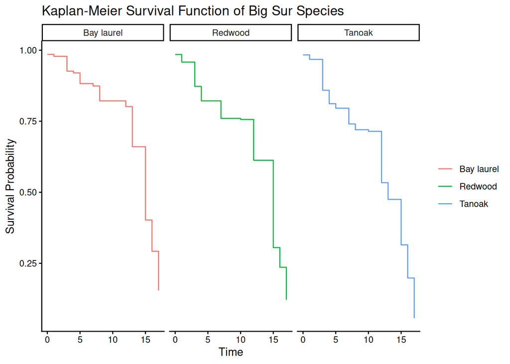

```r
s1 <- survfit2(Surv(t,RametFail) ~ Species, data=tree1)

s1 |>
  ggsurvfit() +
  facet_wrap(~strata) +
  theme_classic() +
  labs(title="Kaplan-Meier Survival Function of Big Sur Species", x="Time")
```

```r
#export_image(p1, "surv.png")

summary(s1)
```

```
Call: survfit(formula = Surv(t, RametFail) ~ Species, data = tree1)

                Species=Bay laurel
 time n.risk n.event survival  std.err lower 95% CI upper 95% CI
    0  26193     385    0.985 0.000744        0.984        0.987
    1  22175     153    0.979 0.000919        0.977        0.980
    3  20619    1101    0.926 0.001762        0.923        0.930
    4  18390     121    0.920 0.001835        0.917        0.924
    5  17616     719    0.883 0.002232        0.878        0.887
    7  14782     143    0.874 0.002322        0.870        0.879
    8  14053     841    0.822 0.002797        0.816        0.827
   12  10813     265    0.802 0.002990        0.796        0.807
   13   9872    1742    0.660 0.003940        0.652        0.668
   15   5824    2274    0.402 0.004856        0.393        0.412
   16   3260     891    0.292 0.004724        0.283        0.302
```

[output cut: 31 more lines]

```r
survdiff(Surv(t, RametFail) ~ Species, data = tree1)
```

```
Call:
survdiff(formula = Surv(t, RametFail) ~ Species, data = tree1)

                       N Observed Expected (O-E)^2/E (O-E)^2/V
Species=Bay laurel 26193     9209    12087   685.475  1249.773
Species=Redwood    20836     8527     8479     0.276     0.442
Species=Tanoak     39700    21158    18328   437.004  1044.174

 Chisq= 1416  on 2 degrees of freedom, p= <2e-16
```